# Projet Tuteuré : Analyse des ressources hospitalières en chirurgie

Hugo Maury, Léo Bernardeau

09 mai 2024

*Sources :*

- https://data.drees.solidarites-sante.gouv.fr/explore/dataset/708_bases-statistiques-sae/information/
- Etablissement MCO
- Département français (MCO)

Les analyses ont été réalisées grâce au logiciel Rstudio version 4.0.5.

# 1 ) Evolution des ressources

### 1.0.1 - Evolution des lits depuis 2013

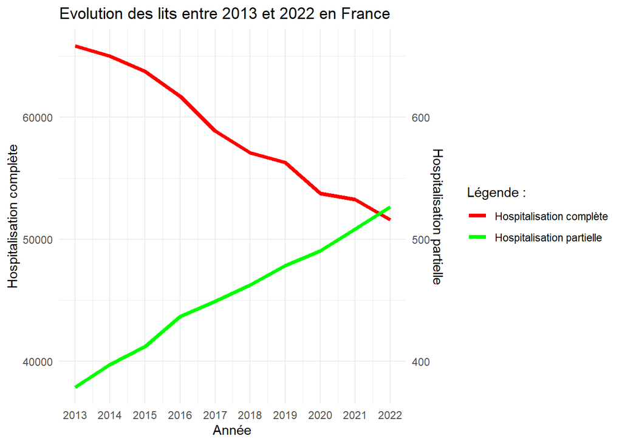

Le nombre de lits en HC tend à diminuer, au contraire du nombre de lits en HP.

### 1.0.2 - Evolution des procédures interventionnelles en imagerie

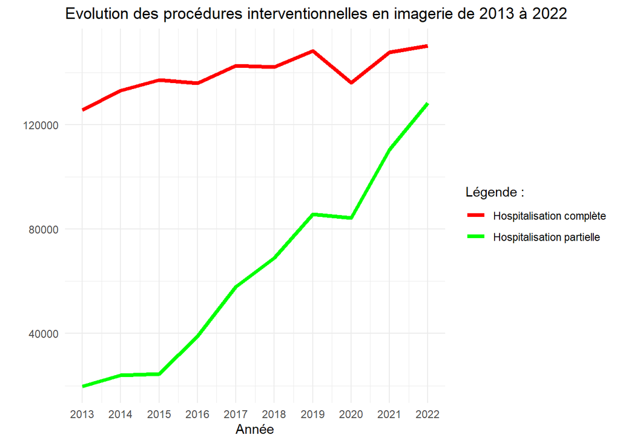

Le nombre d’interventions en HC reste augmente légèrement. Le nombre d’interventions en HP augmente exponentiellement.

# 2 ) Analyse des tendances et des corrélations des lits

### 2.0.1 - Corrélation entre les variables

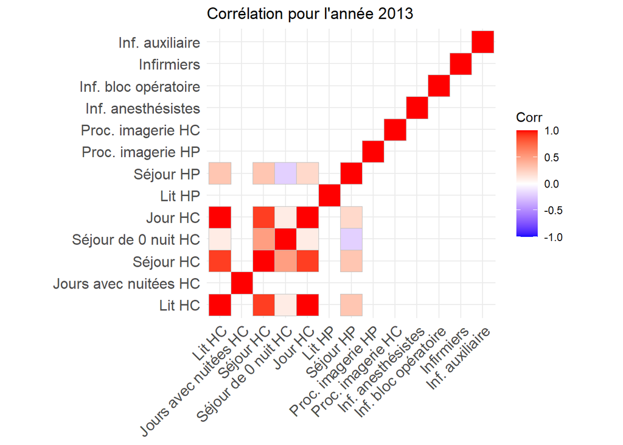

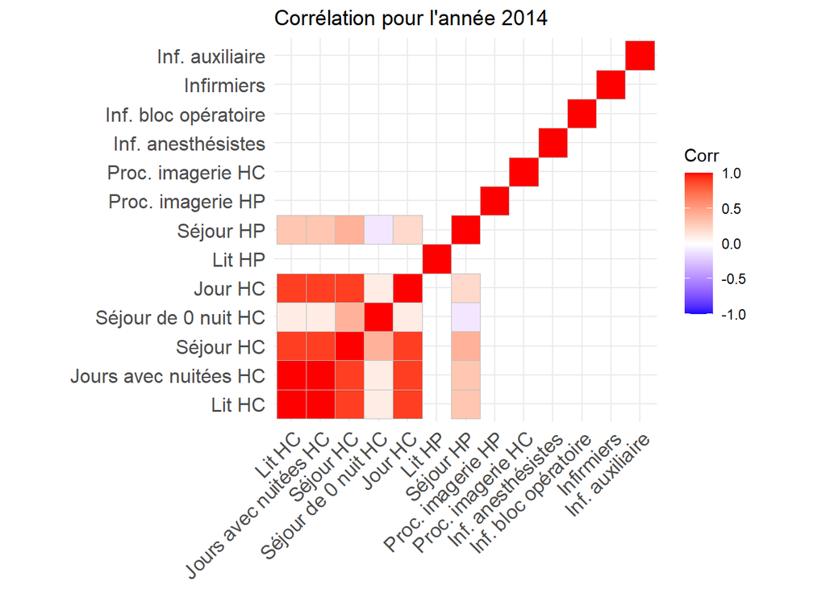

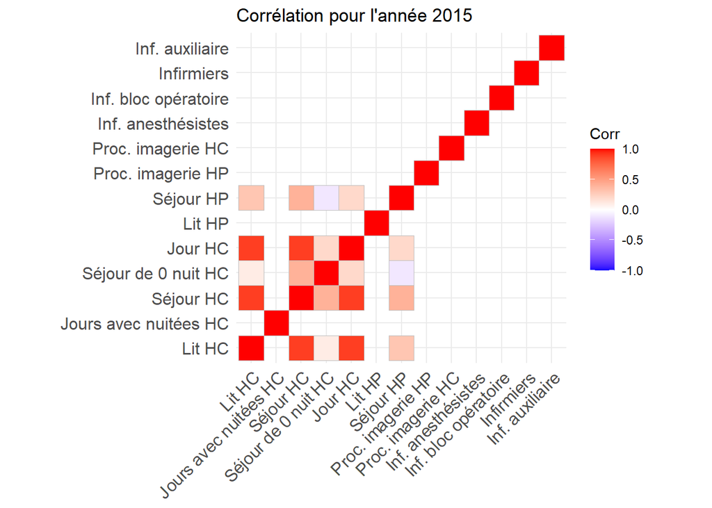

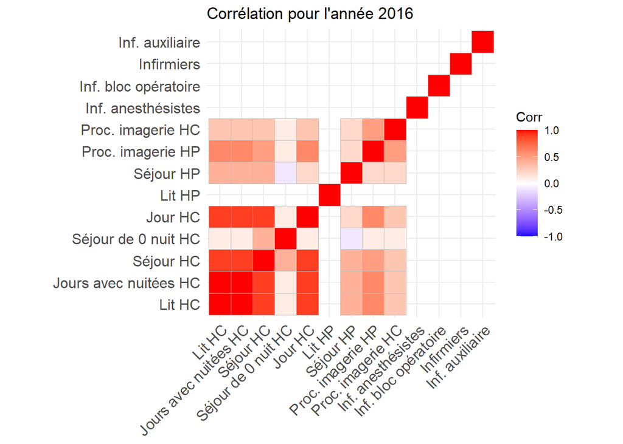

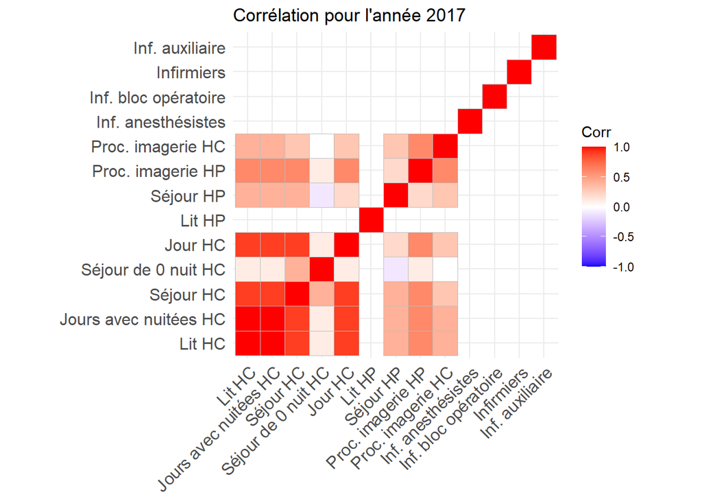

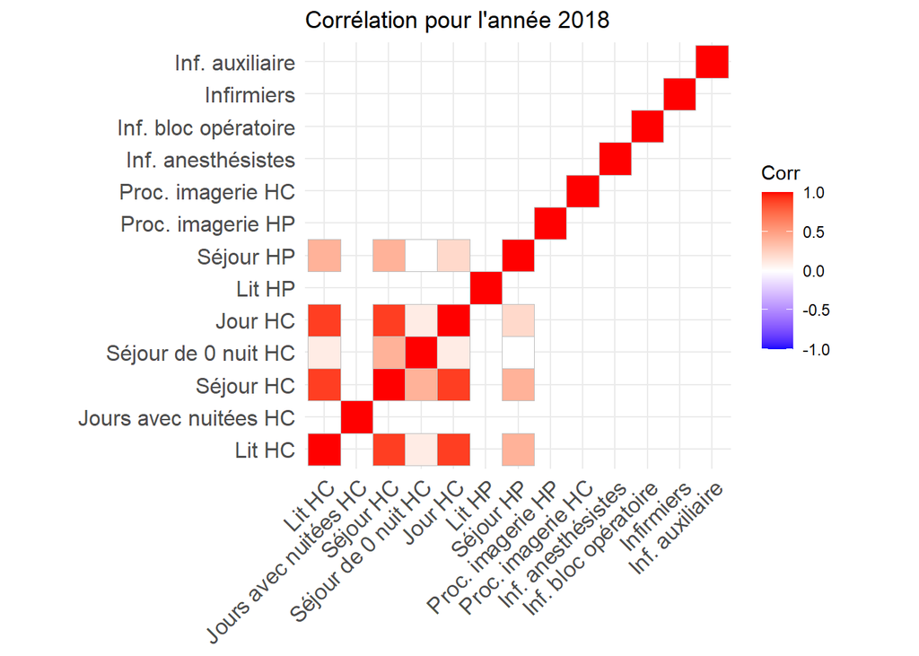

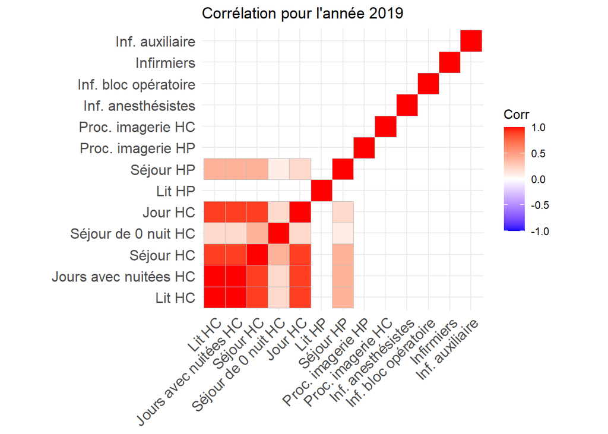

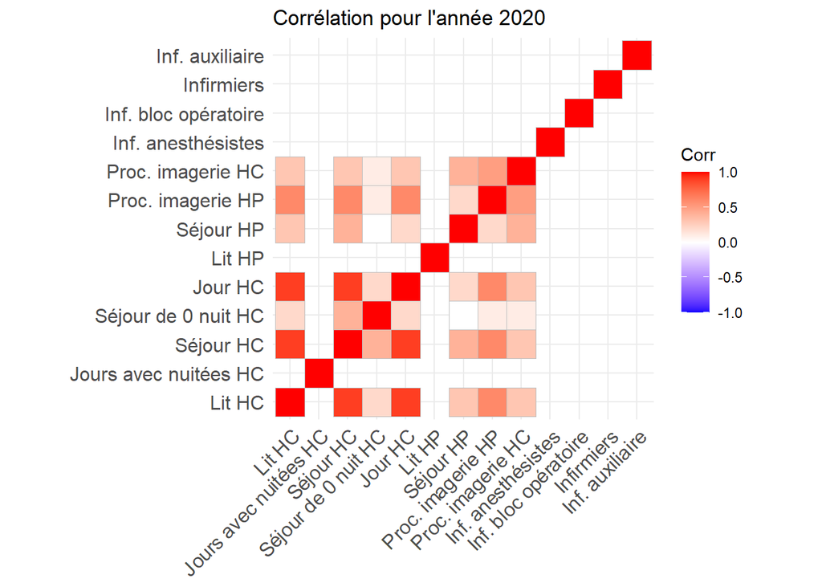

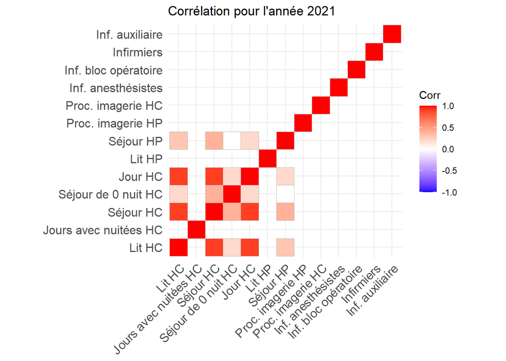

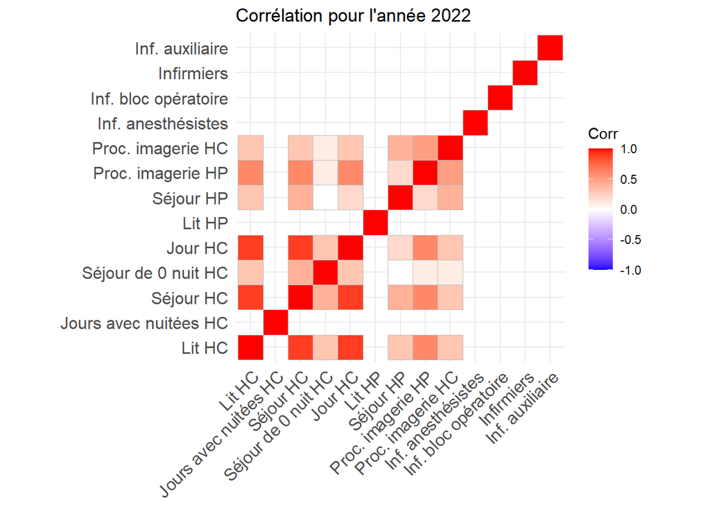

### 2.0.2 - Tendances du nombre de lit

En Hospitalistion complète

| **Variable** | **Coef** | **Intervalle de confiance**<sup>1</sup> | **p-valeur** |
| --- | --- | --- | --- |
| relevel(factor(AN), ref = "2013") |  |  |  |
| 2013 | — | — |  |
| 2014 | -2.2 | -8.3, 3.9 | 0.5 |
| 2015 | -3.8 | -9.9, 2.2 | 0.2 |
| 2016 | -6.5 | -13, -0.42 | 0.036 |
| 2017 | -9.4 | -15, -3.3 | 0.002 |
| 2018 | -12 | -18, -5.7 | <0.001 |
| 2019 | -13 | -19, -7.3 | <0.001 |
| 2020 | -17 | -23, -11 | <0.001 |
| 2021 | -17 | -23, -11 | <0.001 |
| 2022 | -19 | -26, -13 | <0.001 |

<sup>1</sup> CI = Confidence Interval

Modèle : Nombre de lit ~ factor(AN)

En Hospitalisation partielle

| **Variable** | **Coef** | **Intervalle de confiance**<sup>1</sup> | **p-valeur** |
| --- | --- | --- | --- |
| relevel(factor(AN), ref = "2013") |  |  |  |
| 2013 | — | — |  |
| 2014 | 0.58 | -0.86, 2.0 | 0.4 |
| 2015 | 1.2 | -0.21, 2.7 | 0.093 |
| 2016 | 2.2 | 0.81, 3.7 | 0.002 |
| 2017 | 3.0 | 1.6, 4.4 | <0.001 |
| 2018 | 3.5 | 2.1, 5.0 | <0.001 |
| 2019 | 4.1 | 2.6, 5.5 | <0.001 |
| 2020 | 4.6 | 3.2, 6.1 | <0.001 |
| 2021 | 5.4 | 3.9, 6.8 | <0.001 |
| 2022 | 6.1 | 4.7, 7.6 | <0.001 |

<sup>1</sup> CI = Confidence Interval

Modèle : Nombre de Place ~ factor(AN)

# 3 ) Analyse des tendances des séjours hospitaliers

### 3.0.1 - Pente des séjours en hospitalisation complète

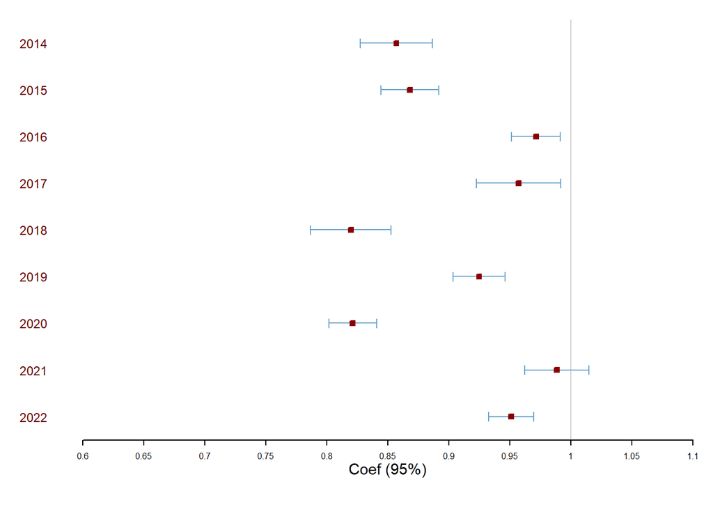

### 3.0.2 - Test de Kendall

Pour les séjours de 0 nuit :

```
## tau = -0.0261, 2-sided pvalue =0.0011563
```

Pour les lits :

```
## tau = -0.112, 2-sided pvalue =< 2.22e-16
```

Avec **tau** = -0.112, et une p_value inférieur à 5%, nous pouvons affirmer que le nombre de lit en HC à diminuer entre 2013 et 2022.

### 3.0.3 - Pente des séjours en hospitalisation partielle

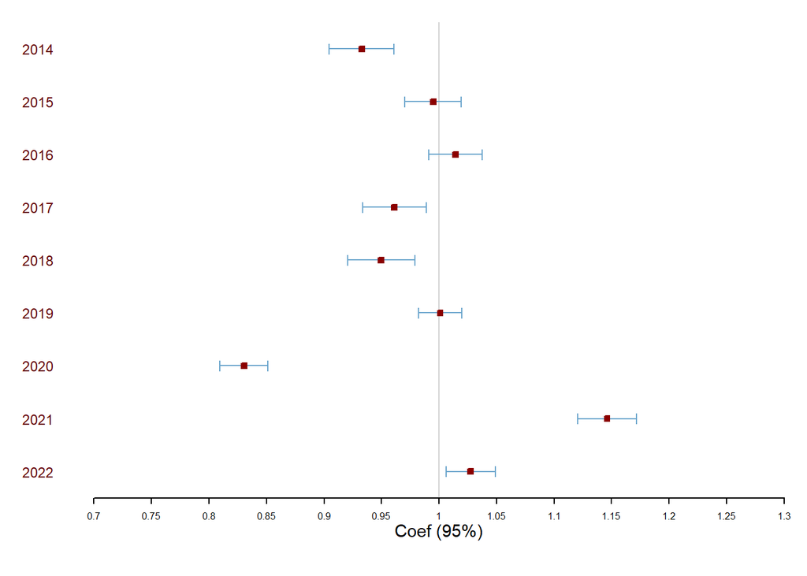

### 3.0.4 - Test de Kendall

Pour les séjours :

```
## tau = 0.0919, 2-sided pvalue =< 2.22e-16
```

Avec **tau** = 0.0919, et une p_value inférieur à 5%, nous pouvons affirmer que le nombre de séjour en HP à augmenter entre 2013 et 2022.

Pour les places :

```
## tau = 0.093, 2-sided pvalue =< 2.22e-16
```

# 4 ) Evolution des ratios des ressources hospitalières

### 4.0.1 - Ratio Infimiers/Nombre de lits

| **Variable** | **Coef** | **Intervalle de confiance**<sup>1</sup> | **p-valeur** |
| --- | --- | --- | --- |
| tot_inf | 1.7 | 1.7, 1.7 | <0.001 |
| factor(AN) |  |  |  |
| 2013 | — | — |  |
| 2014 | -2.2 | -7.2, 2.7 | 0.4 |
| 2015 | -4.9 | -9.8, 0.00 | 0.050 |
| 2016 | -7.7 | -13, -2.8 | 0.002 |
| 2017 | -11 | -16, -5.8 | <0.001 |
| 2018 | -13 | -18, -7.9 | <0.001 |
| 2019 | -13 | -18, -8.4 | <0.001 |
| 2020 | -17 | -22, -12 | <0.001 |
| 2021 | -16 | -21, -11 | <0.001 |
| 2022 | -18 | -23, -13 | <0.001 |

<sup>1</sup> CI = Confidence Interval

Variable sélectionnée : N2200 + N2510 | LIT_CHI + PLA_CHI  
Coef. : 1.7

### 4.0.2 - Ratio Infirmiers/Nombre de Séjour

| **Variable** | **Coef** | **Intervalle de confiance**<sup>1</sup> | **p-valeur** |
| --- | --- | --- | --- |
| tot_inf | 123 | 119, 128 | <0.001 |
| factor(AN) |  |  |  |
| 2013 | — | — |  |
| 2014 | 0.75 | -593, 595 | >0.9 |
| 2015 | 2.7 | -591, 596 | >0.9 |
| 2016 | 166 | -428, 759 | 0.6 |
| 2017 | 194 | -401, 790 | 0.5 |
| 2018 | 414 | -180, 1,007 | 0.2 |
| 2019 | 651 | 59, 1,243 | 0.031 |
| 2020 | -841 | -1,434, -248 | 0.005 |
| 2021 | 501 | -91, 1,093 | 0.10 |
| 2022 | 718 | 121, 1,316 | 0.019 |

<sup>1</sup> CI = Confidence Interval

### 4.0.3 - Ratio Infirmiers/AN

| **Variable** | **Coef** | **Intervalle de confiance**<sup>1</sup> | **p-valeur** |
| --- | --- | --- | --- |
| factor(AN) |  |  |  |
| 2013 | — | — |  |
| 2014 | 0.44 | -3.0, 3.9 | 0.8 |
| 2015 | 1.5 | -1.9, 4.9 | 0.4 |
| 2016 | 1.7 | -1.7, 5.1 | 0.3 |
| 2017 | 2.0 | -1.4, 5.4 | 0.3 |
| 2018 | 2.2 | -1.2, 5.6 | 0.2 |
| 2019 | 1.8 | -1.6, 5.2 | 0.3 |
| 2020 | 2.6 | -0.85, 6.0 | 0.14 |
| 2021 | 2.1 | -1.3, 5.5 | 0.2 |
| 2022 | 3.1 | -0.38, 6.5 | 0.081 |

<sup>1</sup> CI = Confidence Interval

# 5 ) Cartographie

### 5.0.1 - Hospitalisation complète

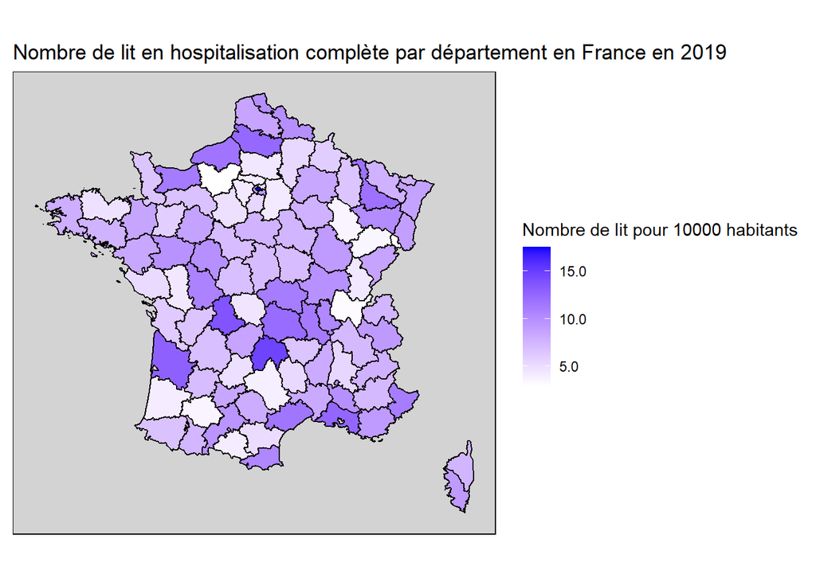

### 5.0.2 - Hospitalisation partielle

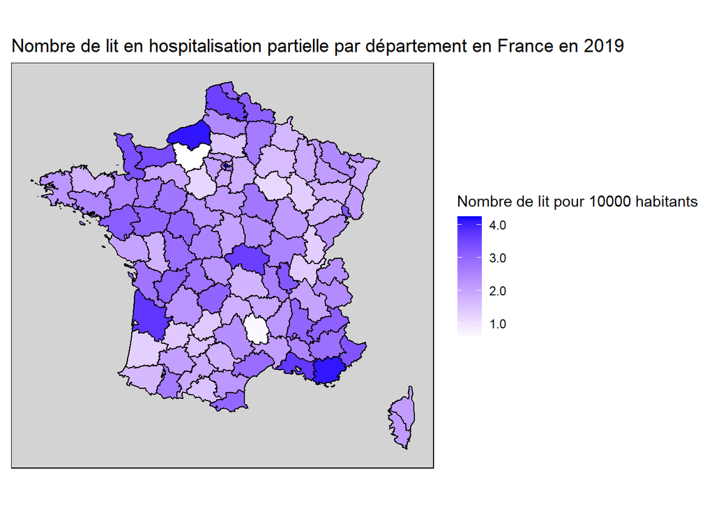

# 6 ) Modèle multi-niveaux

### 6.0.1 Hospitalisation complète

```
## boundary (singular) fit: see help('isSingular')
```

```
## Linear mixed model fit by REML. t-tests use Satterthwaite's method [
## lmerModLmerTest]
## Formula: LIT_CHI ~ 1 + (SEJ0_CHI2) + (STJR) + (AN) + (inf2) + (1 | FI) +
##     (1 | departement) + (1 | region)
##    Data: data
##
## REML criterion at convergence: 57160.6
##
## Scaled residuals:
##      Min       1Q   Median       3Q      Max
## -15.2748  -0.4041  -0.0140   0.3963   8.3417
##
## Random effects:
##  Groups      Name        Variance  Std.Dev.
##  FI          (Intercept) 3.418e+03 5.846e+01
##  departement (Intercept) 1.483e+01 3.850e+00
##  region      (Intercept) 4.653e-08 2.157e-04
##  Residual                1.620e+02 1.273e+01
## Number of obs: 6716, groups:  FI, 764; departement, 96; region, 13
##
## Fixed effects:
##                          Estimate Std. Error         df t value Pr(>|t|)
## (Intercept)            4721.13248  112.29218 5944.99372  42.043  < 2e-16 ***
## SEJ0_CHI2[42 ; 157]       0.52896    0.62585 6033.78503   0.845   0.3980
## SEJ0_CHI2[158 ; 18792]    3.15669    0.72714 6074.40538   4.341 1.44e-05 ***
## STJR2                   -10.56262    4.35462  775.63663  -2.426   0.0155 *
## STJR3                   -10.33652    5.75647 1388.50616  -1.796   0.0728 .
## AN                       -2.30222    0.05564 5935.46156 -41.379  < 2e-16 ***
## inf2[16.7 ; 32.94]        3.74661    0.73036 6149.30288   5.130 2.99e-07 ***
## inf2[32.95 ; 369.99]      7.60274    1.01254 6279.12548   7.509 6.81e-14 ***
## ---
## Signif. codes:  0 '***' 0.001 '**' 0.01 '*' 0.05 '.' 0.1 ' ' 1
##
## Correlation of Fixed Effects:
##               (Intr) SEJ0_CHI2[4;1 SEJ0_CHI2[1;1 STJR2  STJR3  AN     i2[1;3
## SEJ0_CHI2[4;1 -0.025
## SEJ0_CHI2[1;1 -0.059  0.654
## STJR2         -0.016  0.035         0.042
## STJR3         -0.035  0.021         0.021         0.598
## AN            -1.000  0.021         0.055        -0.004  0.019
## i2[16.7;32.    0.031 -0.008        -0.011         0.001  0.001 -0.035
## i2[32.95;36    0.048 -0.008        -0.017         0.017  0.000 -0.052  0.652
## optimizer (nloptwrap) convergence code: 0 (OK)
## boundary (singular) fit: see help('isSingular')
```

### 6.0.2 Hospitalisation Partielle

```r
### Création de 3 groupes pour le nombre de séjour de 0 nuit
# - Infirmiers
# Calculer les quartiles en ignorant les NA
quantile = quantile(data$SEJHP_CHI, probs = c(0, 1/3, 2/3, 1), na.rm = TRUE)
# Utiliser les quartiles pour diviser les données en 3 groupes
groupes = cut(data$SEJHP_CHI, breaks = quantile, labels = c("[0 ; 2532]", "[2533 ; 6024]", "[6024 ; 52975]"), include.lowest = TRUE)
data$SEJHP_CHI2 = groupes

# Modèle
mod_HP = lmer(PLA_CHI ~ 1 + (SEJHP_CHI2) + (STJR) + (AN) + (inf2) + (1 | FI) + (1 | departement) + (1 | region), data = data)
summary(mod_HP)
```

```
## Linear mixed model fit by REML. t-tests use Satterthwaite's method [
## lmerModLmerTest]
## Formula: PLA_CHI ~ 1 + (SEJHP_CHI2) + (STJR) + (AN) + (inf2) + (1 | FI) +
##     (1 | departement) + (1 | region)
##    Data: data
##
## REML criterion at convergence: 42976.6
##
## Scaled residuals:
##     Min      1Q  Median      3Q     Max
## -7.9960 -0.4069 -0.0286  0.3891  6.5319
##
## Random effects:
##  Groups      Name        Variance Std.Dev.
##  FI          (Intercept) 102.0984 10.1044
##  departement (Intercept)   0.9798  0.9898
##  region      (Intercept)   3.1539  1.7759
##  Residual                 25.9814  5.0972
## Number of obs: 6612, groups:  FI, 759; departement, 96; region, 13
##
## Fixed effects:
##                            Estimate Std. Error         df t value Pr(>|t|)
## (Intercept)              -1.280e+03  4.683e+01  5.895e+03 -27.329  < 2e-16 ***
## SEJHP_CHI2[2533 ; 6024]   1.030e+00  2.852e-01  6.413e+03   3.613 0.000306 ***
## SEJHP_CHI2[6024 ; 52975]  4.855e+00  4.086e-01  6.559e+03  11.881  < 2e-16 ***
## STJR2                     1.143e+01  8.090e-01  7.691e+02  14.133  < 2e-16 ***
## STJR3                     6.078e+00  1.233e+00  9.205e+02   4.931 9.73e-07 ***
## AN                        6.400e-01  2.322e-02  5.895e+03  27.557  < 2e-16 ***
## inf2[16.7 ; 32.94]        1.705e+00  2.857e-01  6.534e+03   5.969 2.51e-09 ***
## inf2[32.95 ; 369.99]      3.726e+00  3.862e-01  6.570e+03   9.650  < 2e-16 ***
## ---
## Signif. codes:  0 '***' 0.001 '**' 0.01 '*' 0.05 '.' 0.1 ' ' 1
##
## Correlation of Fixed Effects:
##             (Intr) SEJH;6 SEJH;5 STJR2  STJR3  AN     i2[1;3
## SEJHP_CHI;6  0.163
## SEJHP_CHI;5  0.255  0.632
## STJR2       -0.066 -0.141 -0.249
## STJR3       -0.040 -0.056 -0.089  0.392
## AN          -1.000 -0.166 -0.257  0.058  0.035
## i2[16.7;32.  0.005 -0.039 -0.077  0.022  0.008 -0.009
## i2[32.95;36  0.014 -0.067 -0.107  0.059  0.020 -0.017  0.643
```

```r
# Pour expliquer les parts de variances
library(performance)
icc(mod_HC, by_group = TRUE)
```

```
## # ICC by Group
##
## Group       |       ICC
## -----------------------
## FI          |     0.951
## departement |     0.004
## region      | 1.295e-11
```

```r
icc(mod_HP, by_group = TRUE)
```

```
## # ICC by Group
##
## Group       |   ICC
## -------------------
## FI          | 0.772
## departement | 0.007
## region      | 0.024
```

# 7 AUTRE